# Лабораторная №2

Администрирование сетевых подсистем

Жибицкая Е.Д.

Российский университет дружбы народов, Москва, Россия

# Цель

## Цель работы

- Приобретение навыков по установке и конфигурированию DNS-сервера
- Усвоение принципов работы системы доменных имён на ОС Rocky Linux

# Ход работы

## Подготовка

Для начала загружаем операционную систему, переходим в каталог Vagrant

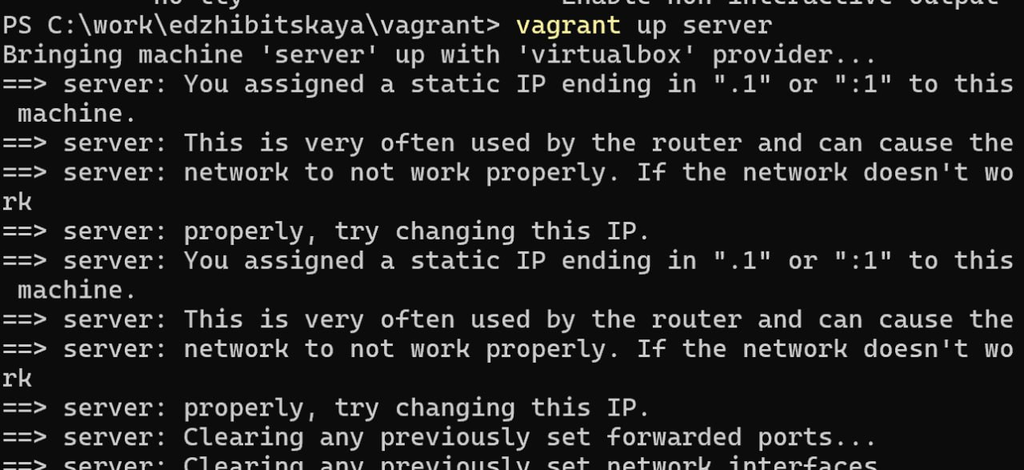

Загрузка ОС

## Начало работы

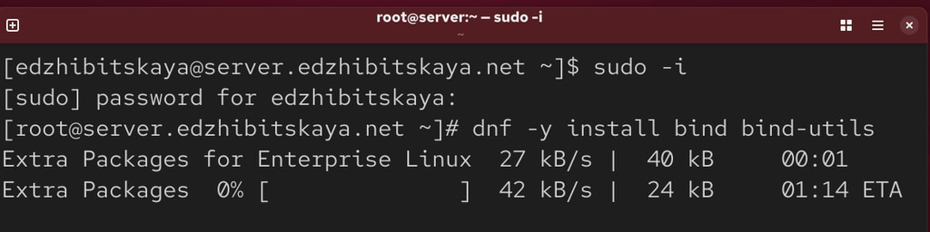

bind, bind-utils

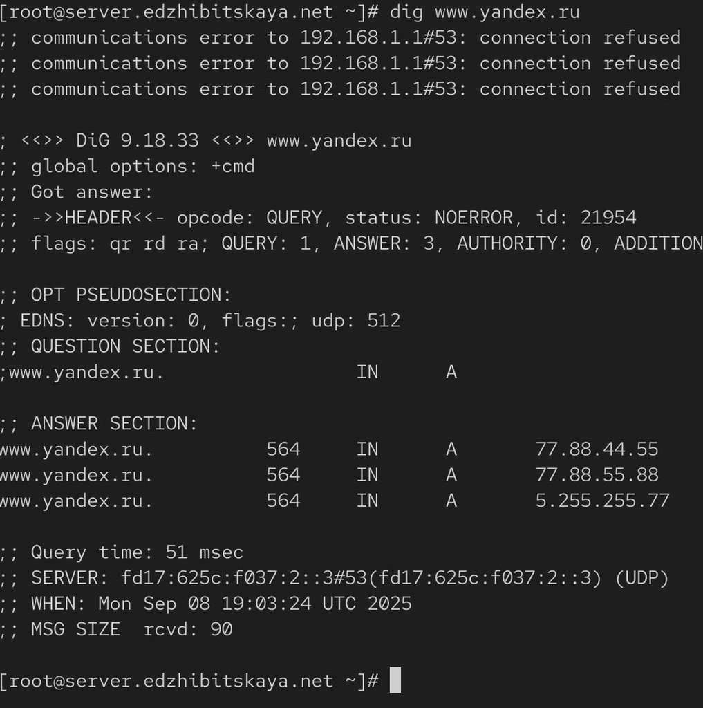

Запрос к DNS-адресу Яндекса

## Просмотр содержимого файлов

В файле /etc/resolv.conf указано к каким DNS-серверам обращаться для преобразования доменных имен в IP-адреса и наоборот

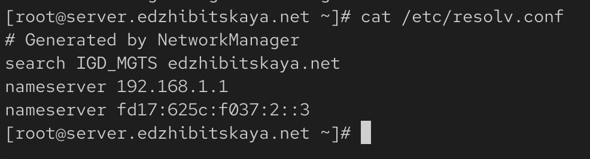

Файл /etc/resolv.conf

## Просмотр содержимого файлов

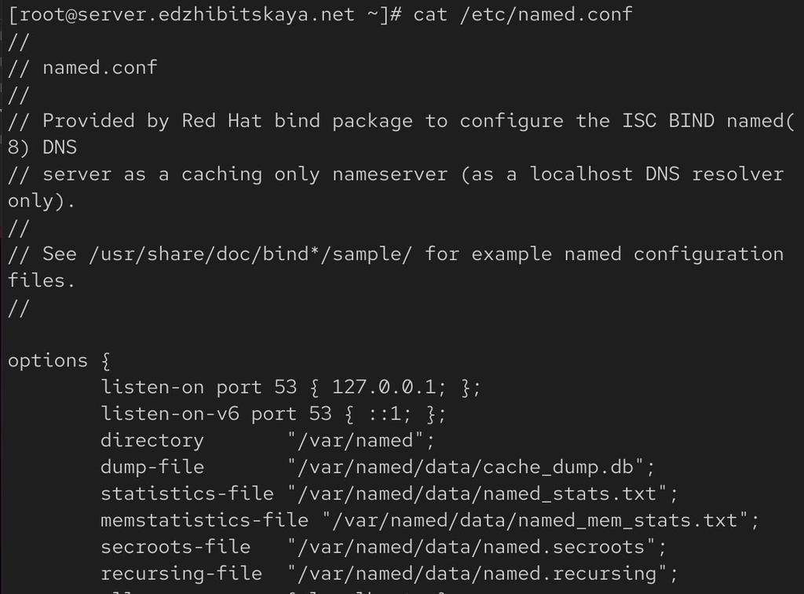

Файл /etc/named.conf

/etc/named.conf - главный конфигурационный файл демона BIND (named). Он определяет общие параметры работы DNS-сервера, зоны, которые он обслуживает, и политики доступа

## Просмотр содержимого файлов

/var/named/named.localhost - это файл прямой зоны для домена localhost. Он сопоставляет имя localhost с IP-адресом 127.0.0.1

/var/named/named.loopback - это файл обратной зоны, выполняет обратное преобразование

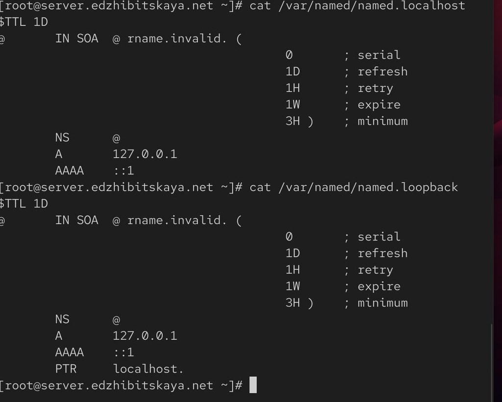

Файлы named.localhost и named.loopback

## Запуск DNS-сервера

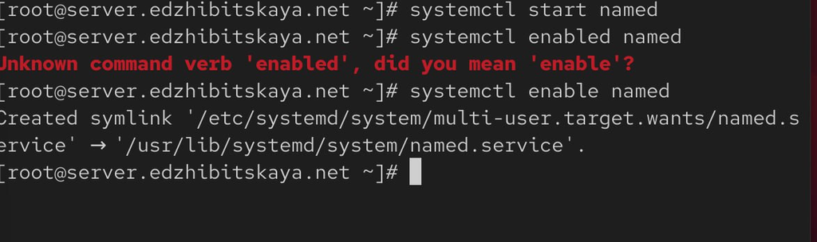

Запуск сервера

## Анализ dig

Проанализируем вывод команд dig www.yandex.ru и dig @127.0.0.1 www.yandex.ru. Вторая команда дает больший вывод, так как в ней мы еще указываем к какому серверу обращаться, она помогает в отладке и диагностике конфигурации

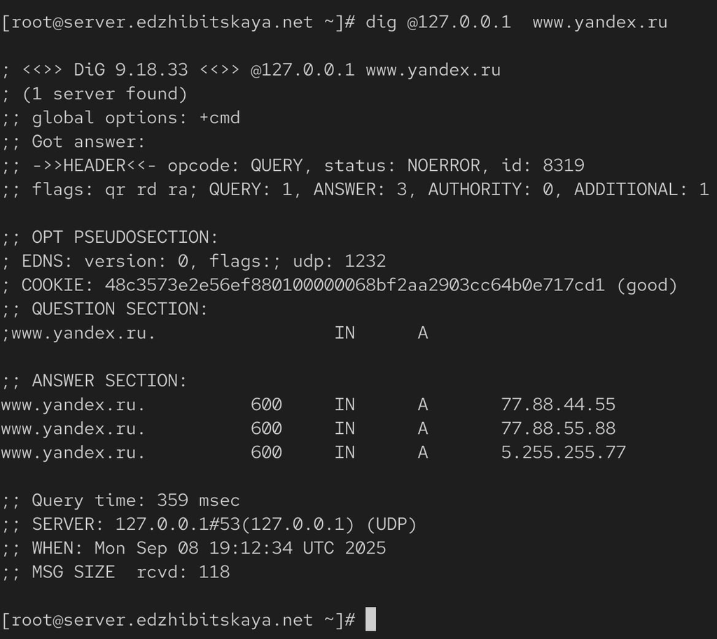

Dig www.yandex.ru

## Настройка соединения

Далее сделаем DNS-сервер сервером по умолчанию для хоста server и внутренней виртуальной сети

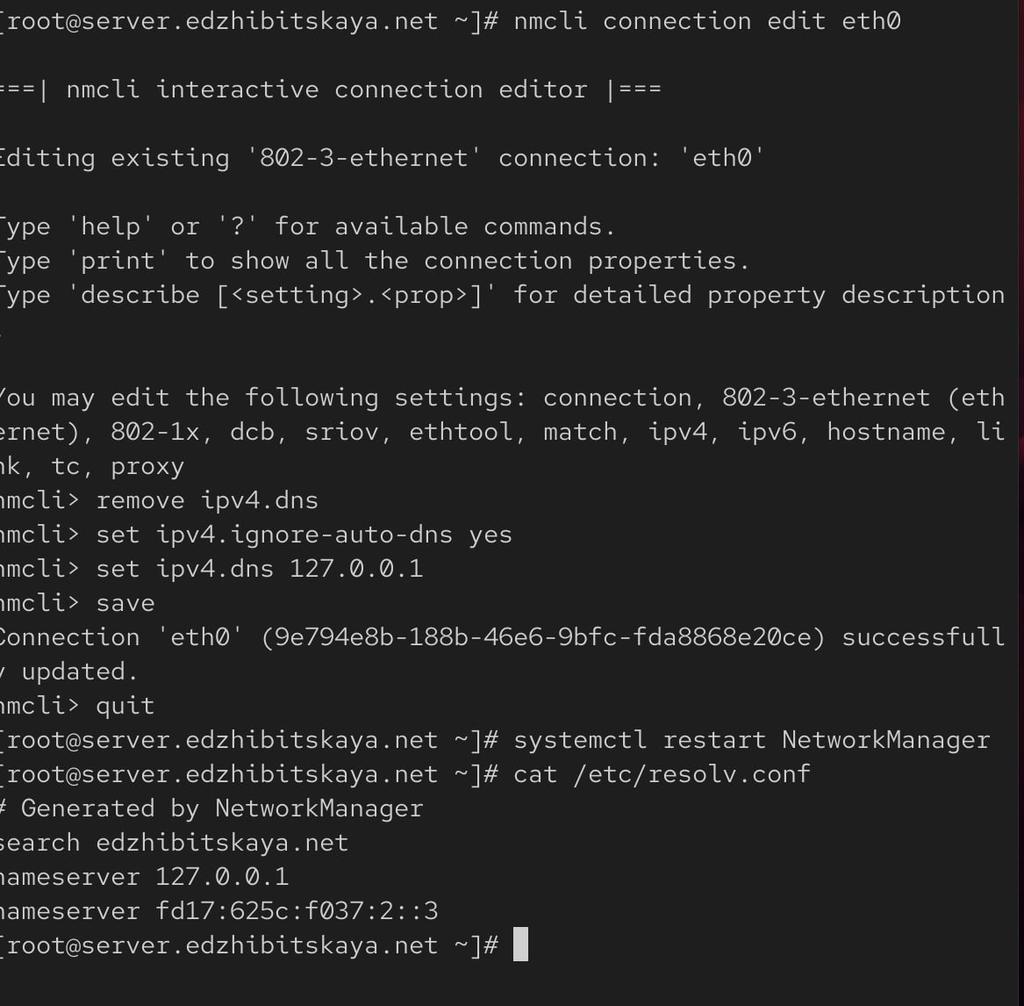

Настройка соединения

## Направления запросов

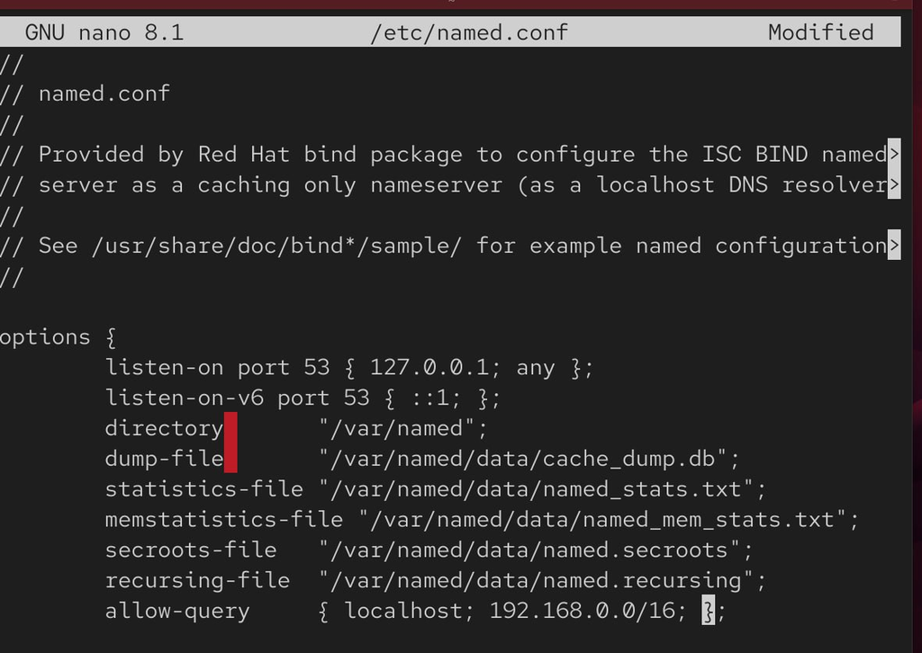

Настройка направления запросов

Также настраиваем направление DNS-запросов от всех узлов внутренней сети, включая запросы от узла server, через узел server. Для этого редактируем файл /etc/named.conf

## Работа с firewall

Вносим изменения в настройки межсетевого экрана узла server, убеждаемся, что DNS-запросы идут через узел server

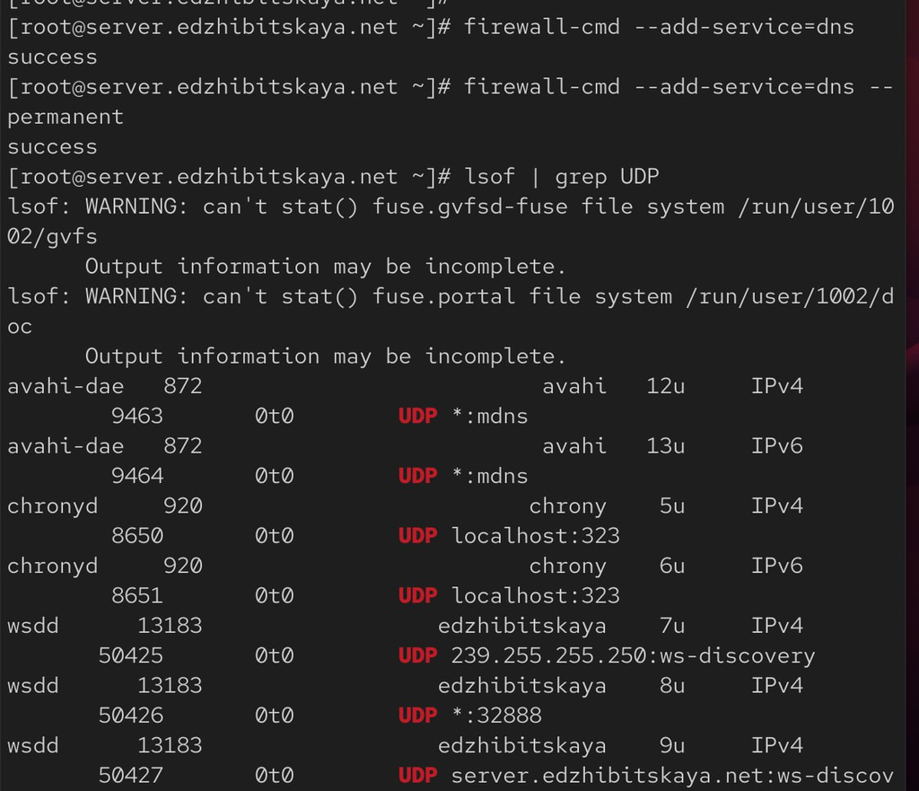

Firewall

## named.conf

В ситуации, когда DNS-запросы от сервера фильтруются сетевым оборудованием, следует добавить перенаправление DNS-запросов на конкретный вышестоящий DNS-сервер

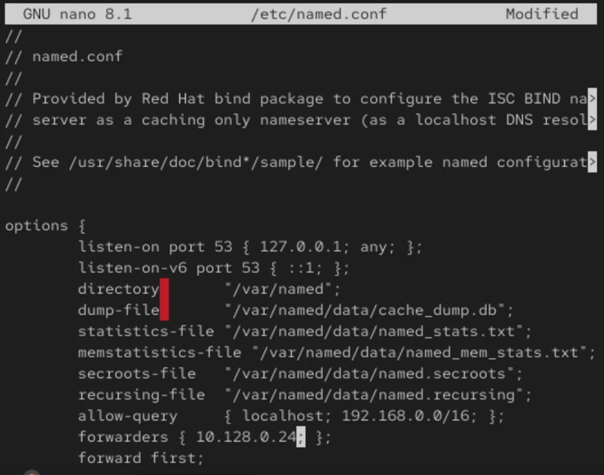

Редактирование named.conf

## Работа с файлами

Далее копируем шаблон описания DNS-зон named.rfc1912.zones из каталога /etc в каталог /etc/named и переименовываем его

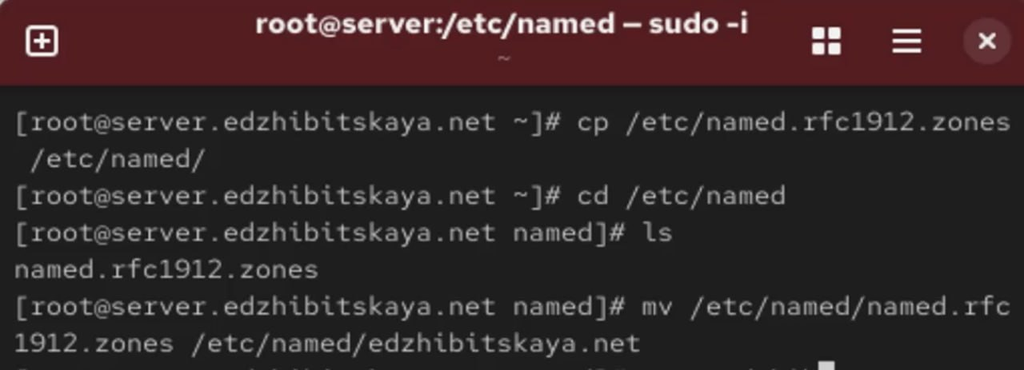

Перемещение файла

## Редактирование файлов

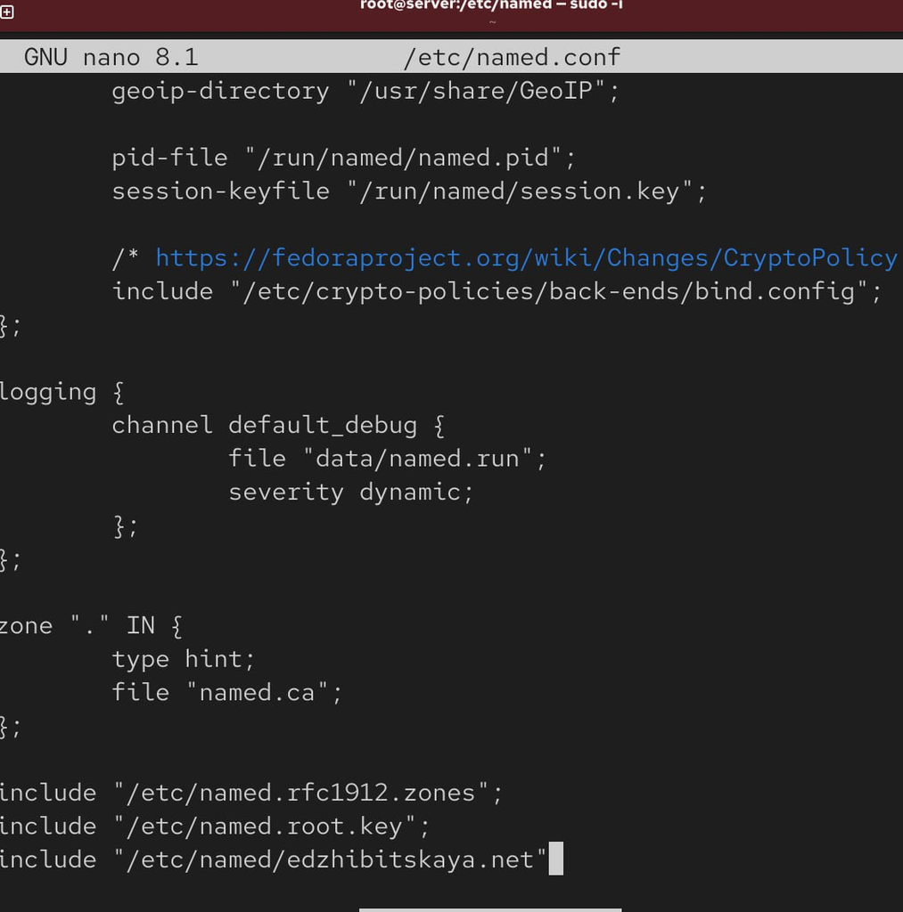

/etc/named.conf

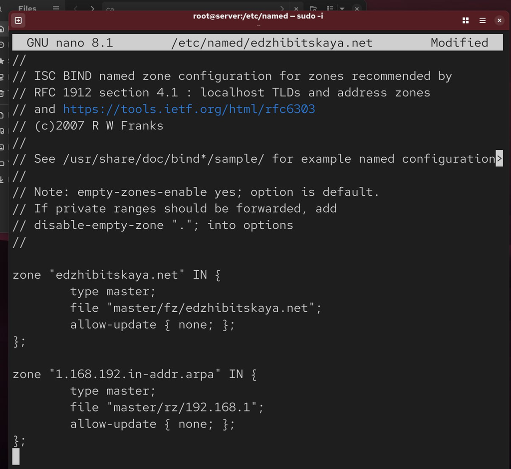

/etc/named/edzhibitskaya.net

## Fz и rz

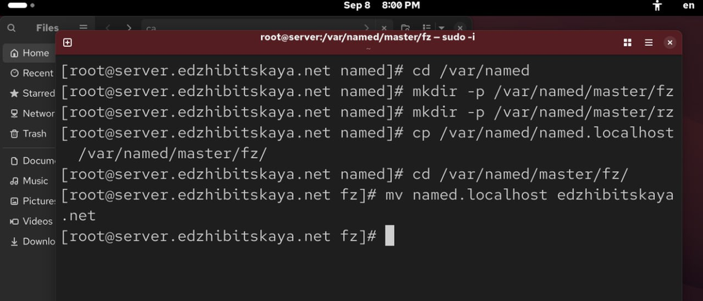

Создание подкаталогов

В каталоге /var/named создаем подкаталоги master/fz и master/rz, в которых будут располагаться файлы прямой и обратной зоны соответственно, скопируем шаблон прямой DNS-зоны named.localhost и переименуем его

## Редактирование edzhibitskaya.net

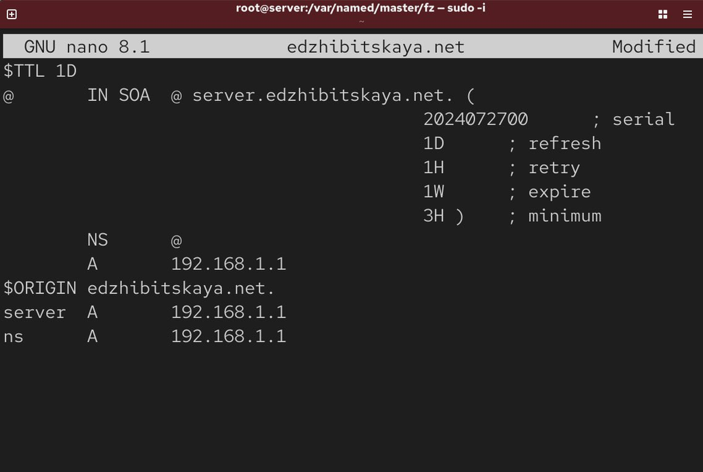

edzhibitskaya.net

## Работа с файлом обратной DNS-зоны

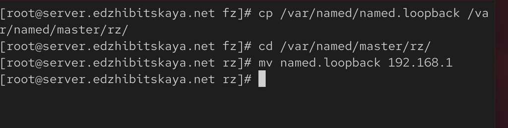

Копирование файла

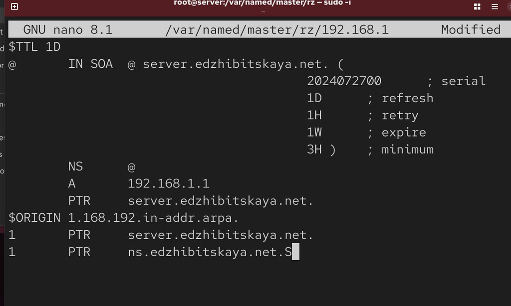

192.168.1

## Наделение прав и метки SELinux

Исправляем права доступа к файлам в каталогах /etc/named и /var/named, чтобы демон named мог с ними работать и после изменения доступа к конфигурационным файлам named корректно восстанавливаем их метки в SELinux

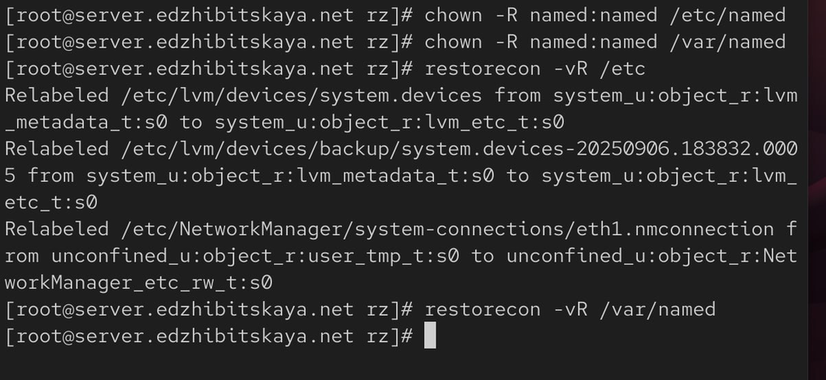

Права и метки

## Переключатели и перезапуск DNS-сервера

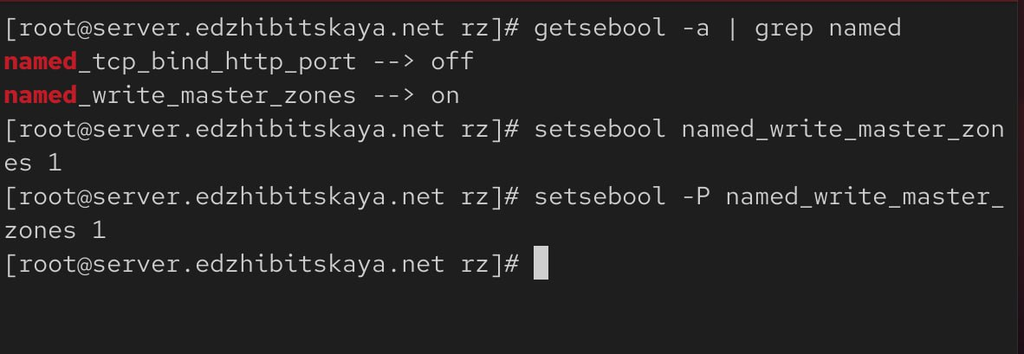

Переключатели

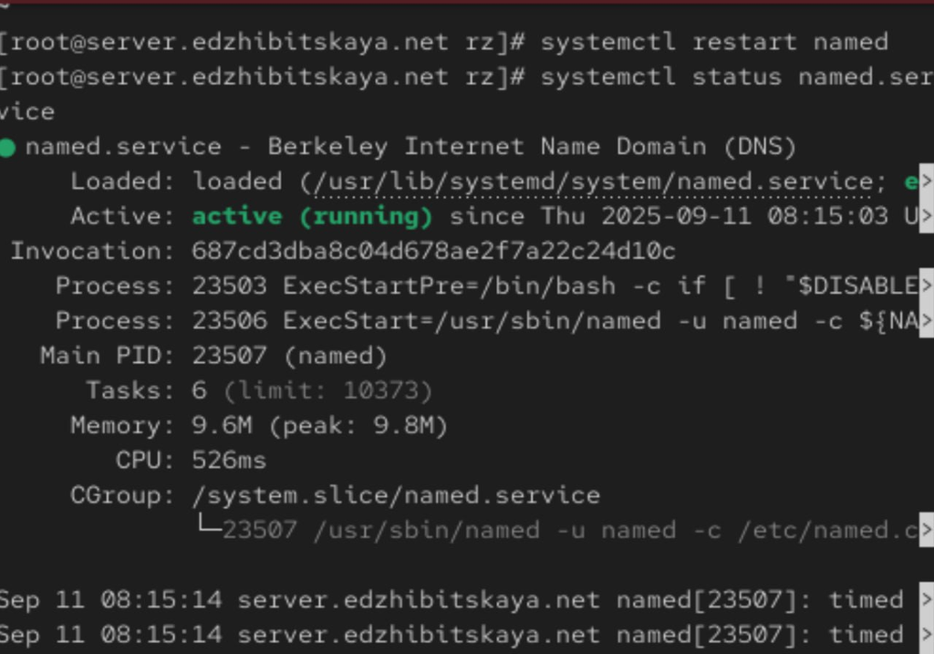

Перезапуск

## Анализ работы DNS-сервера

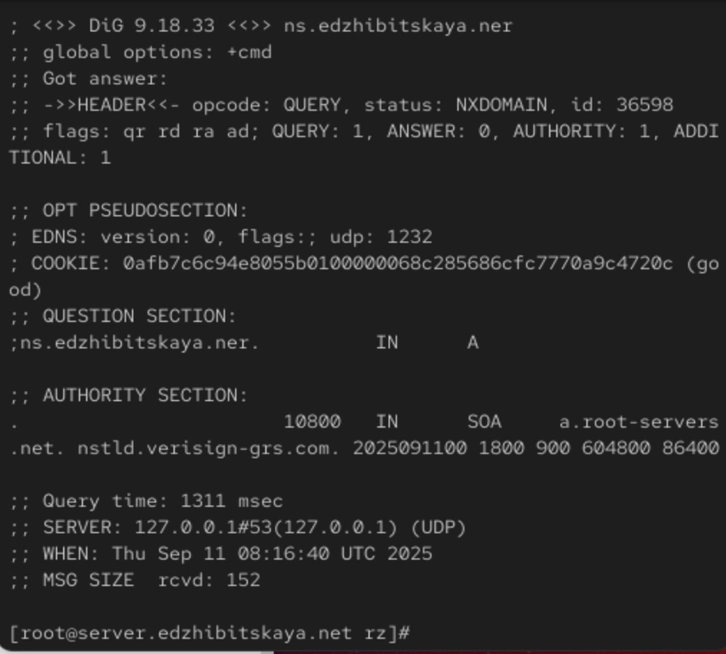

Для анализа работы DNS-сервера воспользуемся утилитами dig и host

## Анализ работы DNS-сервера

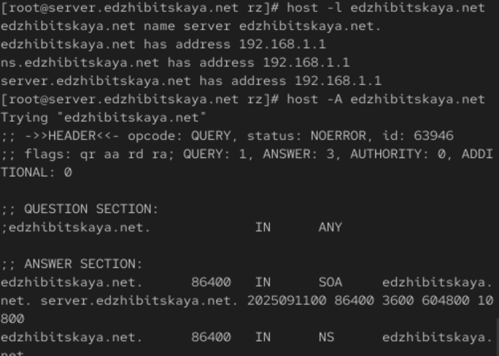

host -l; host -a

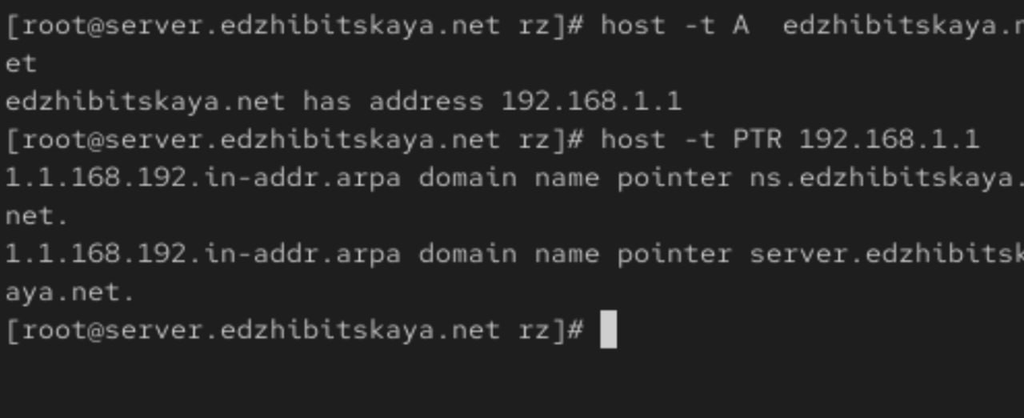

host -t

## Сохранение изменений

Наконец, в каталог для внесения изменений в настройки внутреннего окружения добавим необходимые директории, создадим исполняемый файл и пропишем скрипт.

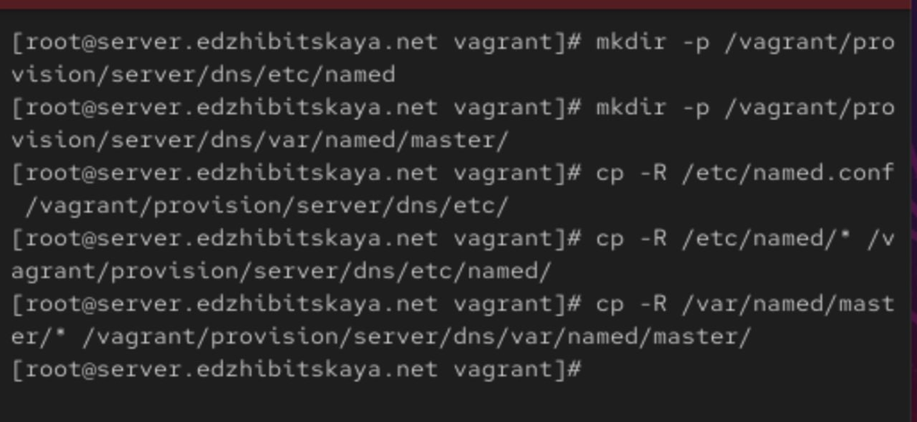

Добавление изменений

## Сохранение изменений

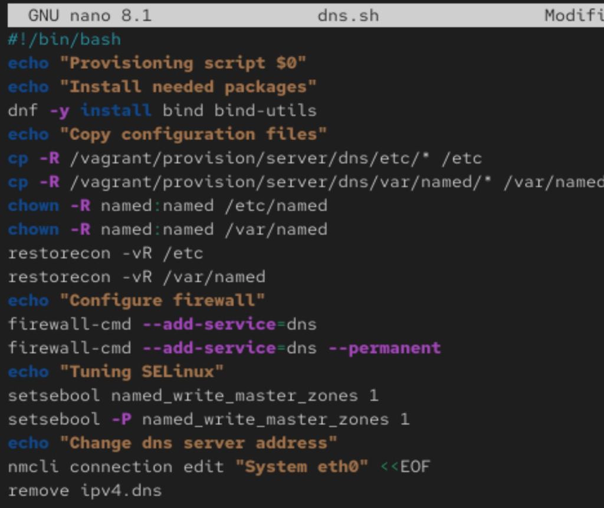

Скрипт

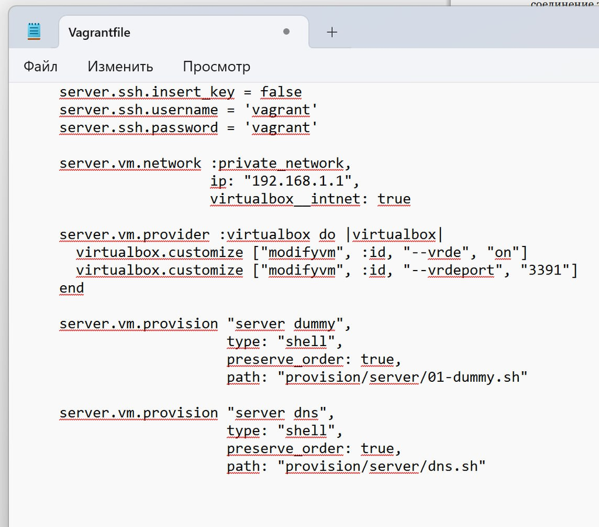

Vagrantfile

# Выводы

## Вывод

- В ходе работы были получены навыки по установке и конфигурированию DNS-сервера и усвоены принципы работы системы доменных имён на ОС Rocky Linux